# Intrapopulation_wCer2_frequency_dynamics

16/12/2022

Sonja Lecic

- Author
- Investigation of intrapolulation frequency dynamics of the wCer2
  - Populations following the expected pattern of frequency change under strong CI
    - Populations starting at high wCer2 frequency (> 0.2)
    - Populations starting at low frequency (p < 0.2)
  - Populations following an unexpected pattern of frequency change under strong CI
    - Populations starting at high wCer2 frequency (p > 0.2)
    - Populations starting at low wCer2 frequency (p < 0.2)
  - Pairwise distances between populations

# Author

author: Sonja Lecic

emmail: slecic8@gmail.com

date: “16/12/2022”

# Investigation of intrapolulation frequency dynamics of the wCer2

```r
# load the libraries
library(ggplot2) # plotting
library(tibble) # data manipulation
library(Hmisc) # statistics
library(circular) # distances calculation
library(ggpubr)
library(geosphere)
```

I first start by calculatting the 95% binomial confidence intervals for the whole dataset. Assuming a binomial distribution I will estimate the exact 95% confidence intervals of p for each population/year using ‘binconf’ function in R package Hmisc.

```r
t2 <- read.csv("/Volumes/LaCie/the_cline/T2transect.csv")
t2.long <- as_tibble(t2)
t2.long.na <- na.omit(t2.long)
for(i in 1:nrow(t2.long.na)){

#Estimate infection freq. and 95% binomial confidence intervals
t2.long.na[i,11] <- binconf(x=as.numeric(t2.long.na[i,8]), n=as.numeric(t2.long.na[i,8] + t2.long.na[i,9]))[2]
t2.long.na[i,12] <- binconf(x=as.numeric(t2.long.na[i,8]), n=as.numeric(t2.long.na[i,8] + t2.long.na[i,9]))[3]
}
colnames(t2.long.na) <- c("id", "pop", "latitude", "longitude",
                               "year", "infection", "total", "inf", "uninf", "infectionFreq", "infectionFreq_lowerCI", "infectionFreq_upperCI")
```

I then cacluate the distance by taking the souther-most location (Alt prerau) as the starting point. I then calculate the distance in meters by taking the radius of the Earth into account and convert the distances to km. The distance between the southern-most and the northern-most location is ~ 69km.

```r
dist2 <- c()
for(i in 1:nrow(t2.long.na)) {

  row <- t2.long.na[i,] # extract row

  # approximate radius of earth in km
  R = 6373.0
  lat1 = rad(48.79926)
  lon1 = rad(16.49265)
  lat2 = rad(row$latitude)
  lon2 = rad(row$longitude)

  dlon = lon2 - lon1
  dlat = lat2 - lat1

  a = sin(dlat / 2)**2 + cos(lat1) * cos(lat2) * sin(dlon / 2)**2
  c = 2 * atan2(sqrt(a), sqrt(1 - a))
  # distance in meters
  distance = (R * c)*1000
  #print(distance)
  dist2  <- c(dist2, distance) # save as a vector
}
round(dist2/1000,3)
```

```
##  [1]  0.000  0.000  3.970  6.816  6.816  6.605  6.837  6.837 11.401 11.807
## [11] 12.112 12.112 12.112 12.112 15.646 15.646 17.140 17.140 17.140 17.140
## [21] 17.140 17.140 18.059 18.059 18.059 18.865 18.865 18.865 19.512 19.512
## [31] 21.099 21.099 21.099 22.166 24.372 24.372 24.372 24.710 24.710 24.710
## [41] 24.710 25.394 24.730 26.828 26.884 26.884 26.884 26.884 26.884 25.028
## [51] 28.435 28.435 28.435 28.435 27.782 29.303 31.086 31.086 31.086 33.636
## [61] 33.636 33.636 33.636 33.636 33.636 35.614 35.614 35.211 34.744 37.777
## [71] 37.563 35.650 40.584 40.584 40.584 40.584 44.881 44.881 44.881 44.881
## [81] 46.561 46.495 46.495 46.495 50.661 50.581 50.581 50.707 54.973 54.973
## [91] 54.973 57.464 57.464 60.856 67.295 68.934
```

```r
# add distance as a column
t2.long.na$dist <- round(dist2/1000,3)
```

Now, we focus on populations with appreciable data; here I subset the populations that have wCer2 infection frequencies recorded for at least 3 sampling years. 16 out of the total of 43 populations pass this filtering step.

```r
#table(t2.long.na$pop)
intrapop3 <- c("Pasohlavky 3",
              "Ivan 2",
              "Ivan-Vranovice 1",
              "Ivan-Vranovice 2 ",
              "Vranovice 2",
              "Prisnotice ",
              "Velke Nemcice 1",
              "NosislavZidlochovice 2",
              "Zidlochovice",
              "Holasice",
              "Rajhrad",
              "Obchodní Centrum Futurum",
              "Brno  Spilberk Castle",
              "Brno  Erbenova",
              "Soběšice 1",
              "Utechov")

t2.long.na.intra3 <- subset(t2.long.na, pop %in% intrapop3)
t2.long.na.intra3$pop <- factor(t2.long.na.intra3$pop, levels=intrapop3)
```

Because there are 16 populations I plot the frequency change (y axis) over time (x axis) for each population separately. I then inspect which populations follow the expected pattern of frequency change over time. The order of populations from left to right (also in the legend from top to bottom) reflects the position of each population along the cline in the South-North direction.

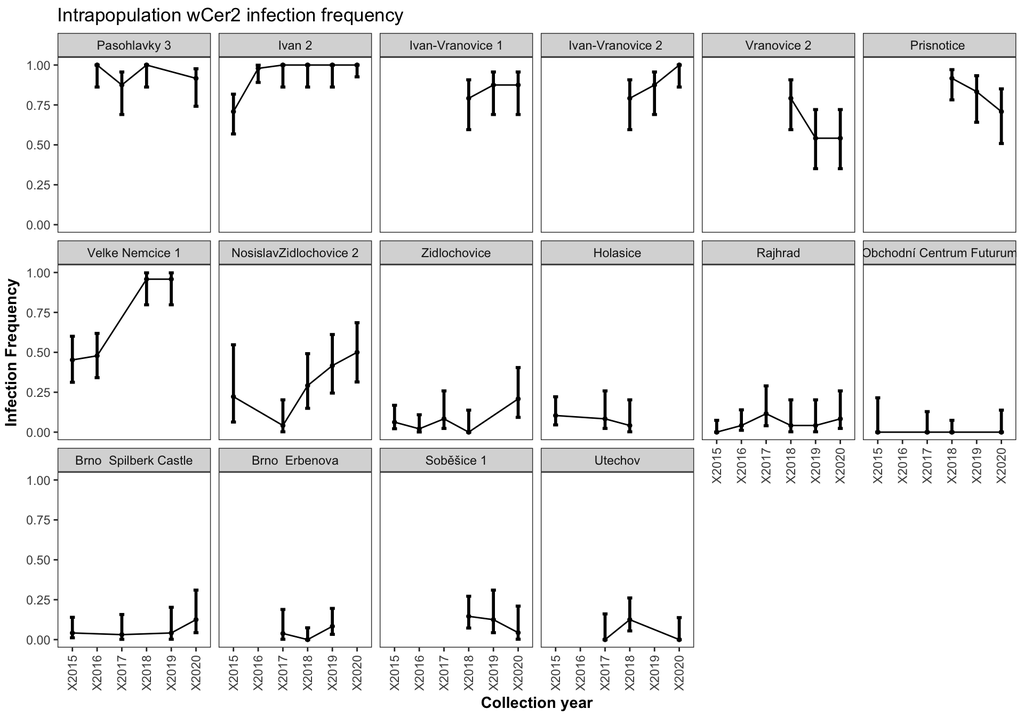

```r
# pairwise comparisons of means

#prm <- compare_means(infectionFreq ~ year, group.by="pop", data = t2.long.na.intra3)
#prm <- as.data.frame(prm)

intrapop2 <- ggplot(t2.long.na.intra3, aes(x=year, y=infectionFreq, group = pop)) +
  geom_errorbar(aes(ymin=infectionFreq_lowerCI,
                    ymax=infectionFreq_upperCI),
                width=.2, size=1) +
  geom_point(size=1) +
  geom_line() +
  theme_bw() +
  theme(axis.title.y = element_text(vjust= 1.8),
        axis.title.x = element_text(vjust= 0.5),
        axis.text.x = element_text(angle = 90, vjust= 0.5),
        axis.title = element_text(face = "bold"),
        panel.grid.major = element_blank(),
        panel.grid.minor = element_blank()) +
  labs(y = "Infection Frequency", x = "Collection year") +
  facet_wrap(~pop, nrow=3) +
  ggtitle("Intrapopulation wCer2 infection frequency")
  #stat_compare_means(label.y = 50)
intrapop2
```

## Populations following the expected pattern of frequency change under strong CI

### Populations starting at high wCer2 frequency (> 0.2)

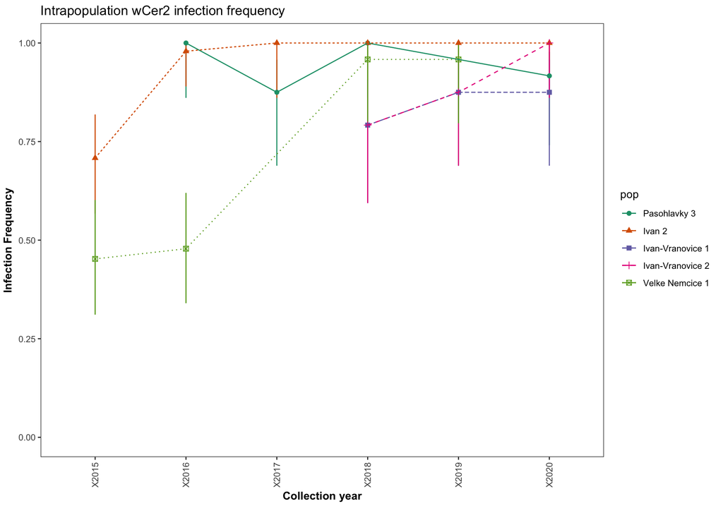

```r
popexp <- c("Pasohlavky 3",
              "Ivan 2",
              "Ivan-Vranovice 1",
              "Ivan-Vranovice 2 ",
              "Velke Nemcice 1")
t2.long.na.intra3.exp <- subset(t2.long.na.intra3, pop %in% popexp)
intrapop1 <- ggplot(t2.long.na.intra3.exp, aes(x=year, y=infectionFreq, group = pop, col=pop)) +
  geom_errorbar(aes(ymin=infectionFreq_lowerCI,
                    ymax=infectionFreq_upperCI),
                width=.01, size=0.5) +
  geom_point(size=2, aes(shape=pop)) +
  geom_line(aes(linetype=pop)) +
  theme_bw() +
  theme(axis.title.y = element_text(vjust= 1.8),
        axis.title.x = element_text(vjust= 0.5),
        axis.text.x = element_text(angle = 90, vjust= 0.5),
        axis.title = element_text(face = "bold"),
        panel.grid.major = element_blank(),
        panel.grid.minor = element_blank()) +
  scale_y_continuous(limits = c(0, 1)) +
  labs(y = "Infection Frequency", x = "Collection year") +
  scale_color_brewer(palette = "Dark2") +
  #facet_wrap(~pop, nrow=3) +
  ggtitle("Intrapopulation wCer2 infection frequency")
intrapop1
```

### Populations starting at low frequency (p < 0.2)

Populations “Zidlochovice”, “Holasice”, “Rajhrad”, “Brno Spilberk Castle”, “Brno Erbenova”, “Soběšice 1”, “Utechov” with wCer2 infections frequency below 20% fluctuate at low frequencies across the colletions years. I will plot these populations here.

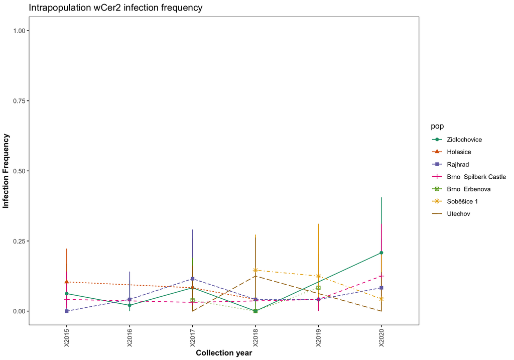

```r
popexp <- c("Zidlochovice",
              "Holasice",
              "Rajhrad",
              "Brno  Spilberk Castle",
              "Brno  Erbenova",
            "Soběšice 1",
            "Utechov")
t2.long.na.intra3.exp <- subset(t2.long.na.intra3, pop %in% popexp)
intrapop1 <- ggplot(t2.long.na.intra3.exp, aes(x=year, y=infectionFreq, group = pop, col=pop)) +
  geom_errorbar(aes(ymin=infectionFreq_lowerCI,
                    ymax=infectionFreq_upperCI),
                width=.01, size=0.5) +
  geom_point(size=2, aes(shape=pop)) +
  geom_line(aes(linetype=pop)) +
  theme_bw() +
  theme(axis.title.y = element_text(vjust= 1.8),
        axis.title.x = element_text(vjust= 0.5),
        axis.text.x = element_text(angle = 90, vjust= 0.5),
        axis.title = element_text(face = "bold"),
        panel.grid.major = element_blank(),
        panel.grid.minor = element_blank()) +
  scale_y_continuous(limits = c(0, 1)) +
  labs(y = "Infection Frequency", x = "Collection year") +
  scale_color_brewer(palette = "Dark2") +
  #facet_wrap(~pop, nrow=3) +
  ggtitle("Intrapopulation wCer2 infection frequency")
intrapop1
```

## Populations following an unexpected pattern of frequency change under strong CI

### Populations starting at high wCer2 frequency (p > 0.2)

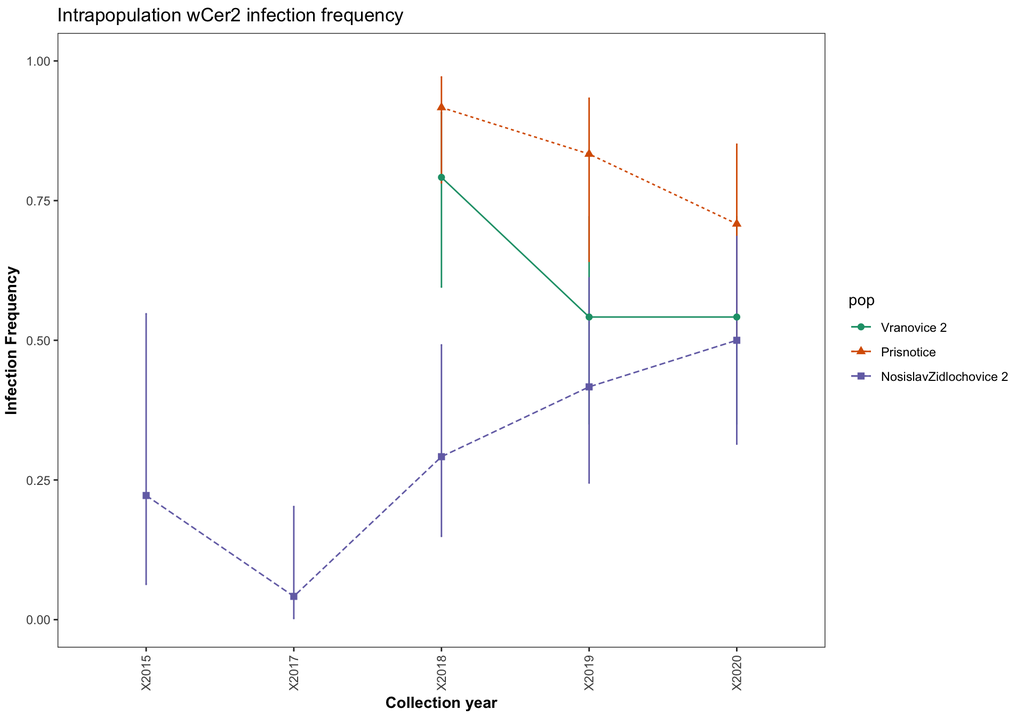

```r
popexp <- c("Vranovice 2",
              "Prisnotice ",
              "NosislavZidlochovice 2")
t2.long.na.intra3.exp <- subset(t2.long.na.intra3, pop %in% popexp)
intrapop1 <- ggplot(t2.long.na.intra3.exp, aes(x=year, y=infectionFreq, group = pop, col=pop)) +
  geom_errorbar(aes(ymin=infectionFreq_lowerCI,
                    ymax=infectionFreq_upperCI),
                width=.01, size=0.5) +
  geom_point(size=2, aes(shape=pop)) +
  geom_line(aes(linetype=pop)) +
  theme_bw() +
  theme(axis.title.y = element_text(vjust= 1.8),
        axis.title.x = element_text(vjust= 0.5),
        axis.text.x = element_text(angle = 90, vjust= 0.5),
        axis.title = element_text(face = "bold"),
        panel.grid.major = element_blank(),
        panel.grid.minor = element_blank()) +
  scale_y_continuous(limits = c(0, 1)) +
  labs(y = "Infection Frequency", x = "Collection year") +
  scale_color_brewer(palette = "Dark2") +
  #facet_wrap(~pop, nrow=3) +
  ggtitle("Intrapopulation wCer2 infection frequency")
intrapop1
```

### Populations starting at low wCer2 frequency (p < 0.2)

Populations “Obchondi Centrum Futurum” stays fixed at 0% infection accross all four collection years. Is this an isolated population? I will plot this populations here.

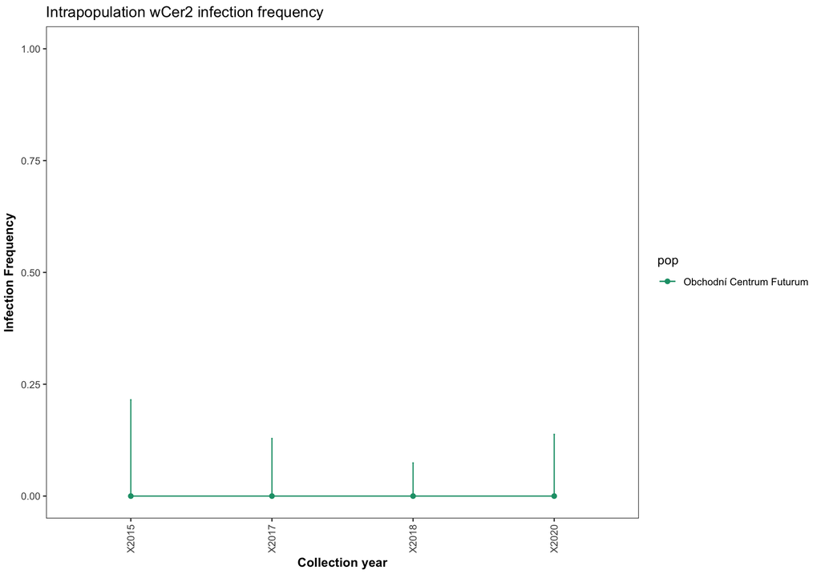

```r
popexp <- c("Obchodní Centrum Futurum")
t2.long.na.intra3.exp <- subset(t2.long.na.intra3, pop %in% popexp)
intrapop1 <- ggplot(t2.long.na.intra3.exp, aes(x=year, y=infectionFreq, group = pop, col=pop)) +
  geom_errorbar(aes(ymin=infectionFreq_lowerCI,
                    ymax=infectionFreq_upperCI),
                width=.01, size=0.5) +
  geom_point(size=2, aes(shape=pop)) +
  geom_line(aes(linetype=pop)) +
  theme_bw() +
  theme(axis.title.y = element_text(vjust= 1.8),
        axis.title.x = element_text(vjust= 0.5),
        axis.text.x = element_text(angle = 90, vjust= 0.5),
        axis.title = element_text(face = "bold"),
        panel.grid.major = element_blank(),
        panel.grid.minor = element_blank()) +
  scale_y_continuous(limits = c(0, 1)) +
  labs(y = "Infection Frequency", x = "Collection year") +
  scale_color_brewer(palette = "Dark2") +
  #facet_wrap(~pop, nrow=3) +
  ggtitle("Intrapopulation wCer2 infection frequency")
intrapop1
```

## Pairwise distances between populations

Here, I cacluate pairwise distances in km between focal populations using geospehre R package for easier estimation of distances between these focal populations.

```r
# extract only populations longitude and latitude
un <- unique(t2.long.na.intra3[, c(2, 3, 4)])
un <- un[-9,]
lonlat <- unique(un[, c(2,3)])
# and create a matrix with pop column as row names
lonlat_mat <- matrix(c(un$longitude, un$latitude), nrow=16, ncol=2,  byrow = T, dimnames = list(intrapop3, c("longitude", "latitude")))

# compute distance matrix using library(geosphere) package
dist <- (distm(lonlat_mat, fun = distGeo))/1000
# add ids
colnames(dist) <- intrapop3
rownames(dist) <- intrapop3

dist
```

```
##                          Pasohlavky 3      Ivan 2 Ivan-Vranovice 1
## Pasohlavky 3                 0.000000    5.654188         7.772444
## Ivan 2                       5.654188    0.000000         2.383836
## Ivan-Vranovice 1             7.772444    2.383836         0.000000
## Ivan-Vranovice 2            14.482474    8.846049         6.798705
## Vranovice 2                  8.378048    2.758064         1.933630
## Prisnotice                   7.348861    1.736710         1.742123
## Velke Nemcice 1              6.603335    1.410355         1.169846
## NosislavZidlochovice 2       9.543775    4.007192         1.795163
## Zidlochovice              3584.590281 3582.953910      3581.149832
## Holasice                  4633.157348 4628.903473      4626.547809
## Rajhrad                   4635.683080 4631.430625      4629.075102
## Obchodní Centrum Futurum  4639.559197 4635.305901      4632.950294
## Brno  Spilberk Castle     4643.973337 4639.722692      4637.367346
## Brno  Erbenova            4650.571495 4646.323279      4643.968172
## Soběšice 1                4662.925477 4658.681624      4656.326950
## Utechov                   4669.346147 4665.103859      4662.749341
##                          Ivan-Vranovice 2  Vranovice 2 Prisnotice
## Pasohlavky 3                     14.482474    8.378048    7.348861
## Ivan 2                            8.846049    2.758064    1.736710
## Ivan-Vranovice 1                  6.798705    1.933630    1.742123
## Ivan-Vranovice 2                  0.000000    6.257236    7.241623
## Vranovice 2                       6.257236    0.000000    1.029665
## Prisnotice                        7.241623    1.029665    0.000000
## Velke Nemcice 1                   7.950847    2.482213    1.763083
## NosislavZidlochovice 2            5.005526    2.089301    2.710627
## Zidlochovice                   3579.562819 3582.677480 3582.882972
## Holasice                       4621.696021 4627.214882 4627.923869
## Rajhrad                        4624.225129 4629.742866 4630.451568
## Obchodní Centrum Futurum       4628.099239 4633.617647 4634.326519
## Brno  Spilberk Castle          4632.519679 4638.035990 4638.744330
## Brno  Erbenova                 4639.123606 4644.637996 4645.345850
## Soběšice 1                     4651.487953 4656.998891 4657.705872
## Utechov                        4657.912339 4663.422040 4664.128708
##                          Velke Nemcice 1 NosislavZidlochovice 2 Zidlochovice
## Pasohlavky 3                    6.603335               9.543775     3584.590
## Ivan 2                          1.410355               4.007192     3582.954
## Ivan-Vranovice 1                1.169846               1.795163     3581.150
## Ivan-Vranovice 2                7.950847               5.005526     3579.563
## Vranovice 2                     2.482213               2.089301     3582.677
```

[output cut: 47 more lines]

```
## Ivan 2                   4665.103859
## Ivan-Vranovice 1         4662.749341
## Ivan-Vranovice 2         4657.912339
## Vranovice 2              4663.422040
## Prisnotice               4664.128708
## Velke Nemcice 1          4663.721267
## NosislavZidlochovice 2   4661.421948
## Zidlochovice             2361.968975
## Holasice                   38.522883
## Rajhrad                    35.601470
## Obchodní Centrum Futurum   32.322558
## Brno  Spilberk Castle      27.102774
## Brno  Erbenova             19.954862
## Soběšice 1                  6.664534
## Utechov                     0.000000
```

#### minimum distance between any two populations

```
## [1] 0
```

#### maximum distance between any two populations

```
## [1] 4669.346
```